# Data Visualization: Final Project

## By: Azaam Jamil, Blake Kappel, Ibrahim Nagib

##### This html page, was produced by creating an R markdown document, and using KnitR to knit the file into html. The purpose of this html file, is to show a visual analysis of our data set in Tableau, R Studio, and Shiny.

### Final Project Folders:

- **00 Doc**
  - rmd and html
- **01 Data**
  - etl.R files
- **03 Tableau Workbooks**
  - .twbx and all .png files of tableau worksheets
- **04 Shiny**
  - ui.R and server.R files for Shiny application
- **Rprofile.R**
  - for simplification (required packages)

### Rprofile.R:

An Rprofile.R document was created to include all of the packages required for the project, in order to avoid requiring packages in each of the R script files. Below is the call to the Rprofile document, and shows the necessary packages being loaded:

```r
source("../Rprofile.R", echo = FALSE)
```

```
##
##
##
##
## Registering fonts with R
```

### Data:

The data set we chose to analyze and visualize is a data set of tested vehicles. A group of 2016 vehicles were tested for various measures including horsepower, carbon emmissions, nitrogen emmisions, engine displacement, and various other measures. For the last few visualizations, the original data set was blended with another data set, showing the fuel consumption(hwy and city) for the same vehicles. We used a modified R_ETL.R file to move the data into an SQL server.

### Our Pre-Analysis hypothesis:

Before starting our analysis, we first discussed some of the results that we expected to see. We discussed what visualizations we wanted, and how the visualizations could help prove or support our hypothesis.  
Expectations:

- positive correlation between horsepower, carbon dioxide emmissions, and N2O emmissions
  - as horsepower increases, we expect to see an overall increase in CO<sup>2</sup>, and N<sup>2</sup>O
- strong positive correlation between egnine displacement, horsepower, and fuel economy
  - naturally, we believe a larger engine will produce more horsepower, and be less fuel efficient.

### Methodology for Data Analysis:

1. Start with a measure in non-aggregated mode and make a Boxplot
2. Start with a measure thing in aggregated mode and make a Histogram
3. Start with two measures and make a Scatter plot
4. Start with two dimensions plus a measure and make a Crosstab
5. Start with a dimension and a measure and make a Barchart

### Box-Plot :

The box-plot below shows a reasonable expectation of car manufacturer’s rated horse powers. As we had predicted, most vehicles are in a mid-range horse power, with few outliers in very low or very high horse power ranges. The exceptions, we found to be manufacturers that made only powerful super cars.

- sorted by median horsepower ascending
- highest median and highest HP is by Pagani Automobil S
- lowest median HP is bluecar SAS

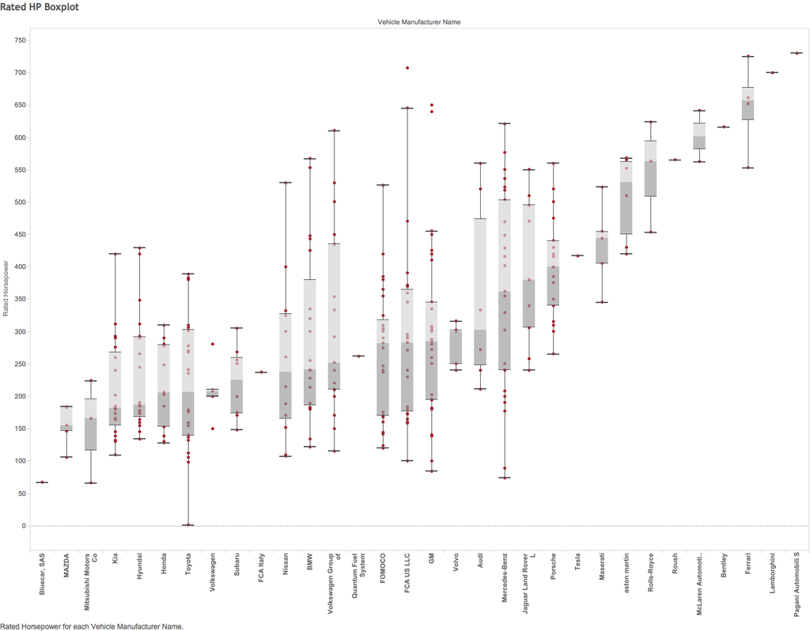

### Histogram :

Below is a histogram showing the normal curve of rated horse power. As expected, most of the vehicles are in the mid range for horsepower, with few vehicles on either tale end of the bell curve.

- Started with a “green thing”" in aggregated mode (count of rated horsepower)
- Count of horsepower : height
- CO<sup>2</sup> emissions : Color
  - shade of blue, the lighter the color the greater the CO<sup>2</sup> emission

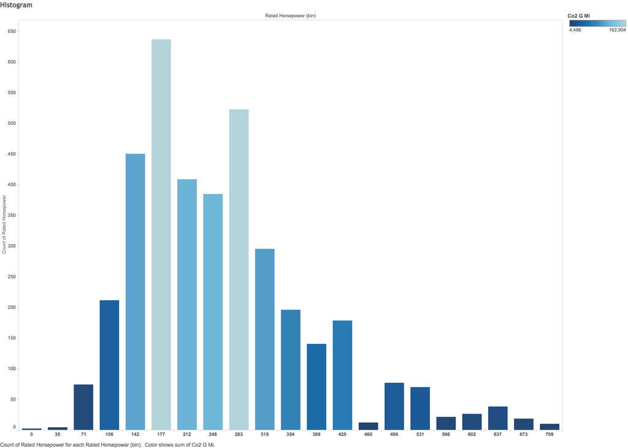

### Scatter Plot:

The scatter plot shows horse power on the x-axis and CO2 emissions on the y-axis. As we expected there is a positive correlation between the two measure variables. The visualization shows a trend of increased carbon dioxide emissions with increases in horesepower. The colors represent different vehicle types, also as expected, trucks tend to have higher emissions than cars.

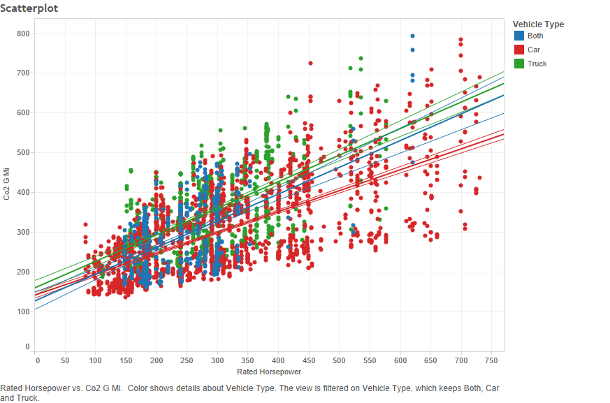

### Cross-Tab :

Below is another visualization of a subset of the data. For this visualization, we wanted to observe a cross tab of vehicle types, car makes, and the calculated engine efficiency of the vehicles. Engine efficiency was a KPI that we calculated by dividing the horsepower by the engine displacement, or size of the engine in Liters. Parameters were set for high and low engine efficiency and used to compare all of the vehicles in the cross-tab.

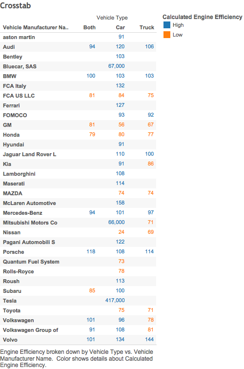

### Bar Graph :

Below is a bar graph of the sum of the rated HP by company overlayed by an average line and individual labels. * Started with Manufacturer name and Rated HP * Labels tell the average HP of the company * Height of bars show the sum of the company’s rated HP * Average sum: 32,809 Overall, this provides a look into the focus of the manufacturer’s themselves. * Do they output more vehicles, but with less HP? * Or do they output less vehicles with higher HP?

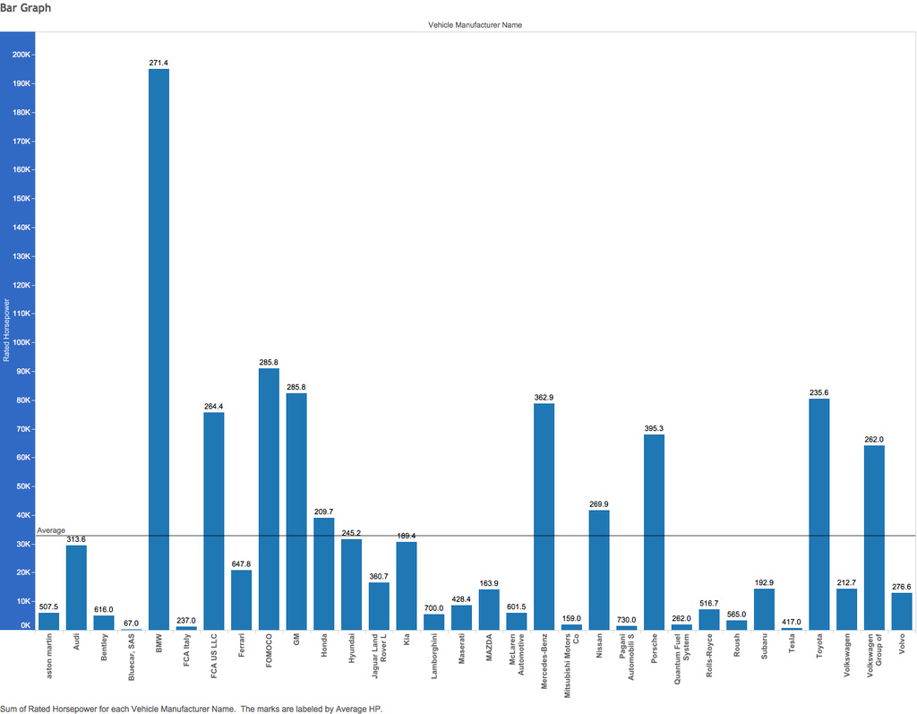

### Shiny App:

We used Shiny, to build an app to demonstrate our more interesting visualizations and group them together in a neat dashboard.  
[Shiny App](https://kappelblake.shinyapps.io/FinalProject)

### Tableau Blended Scatter Plot :

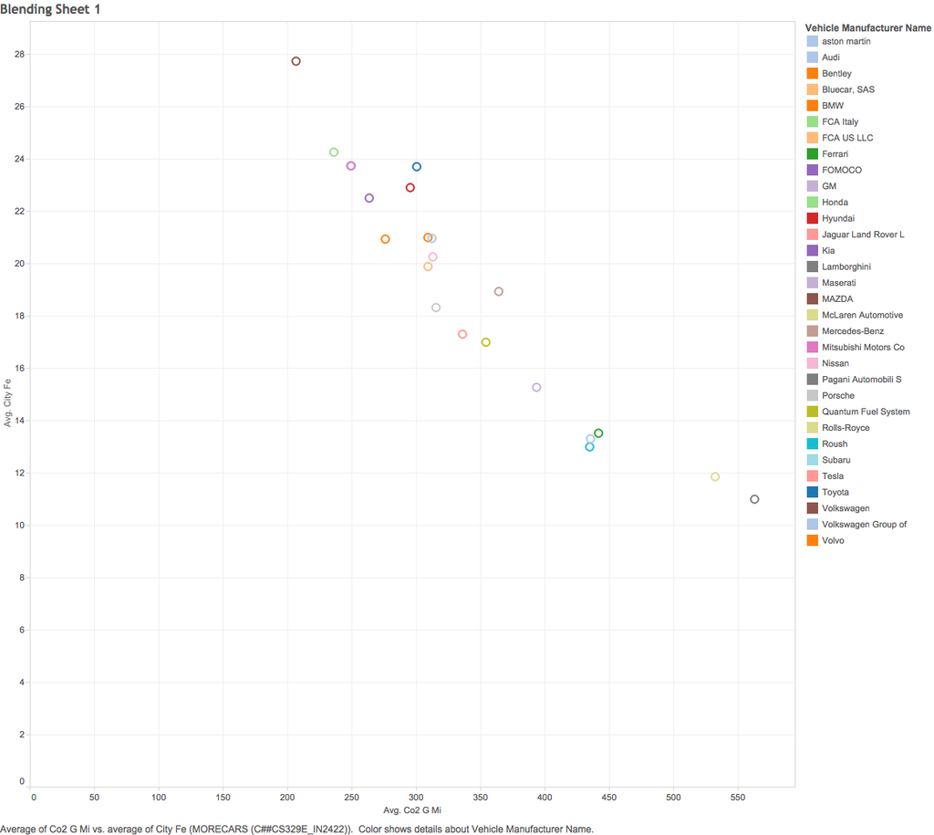

### Tableau Blended Scatter Plot :

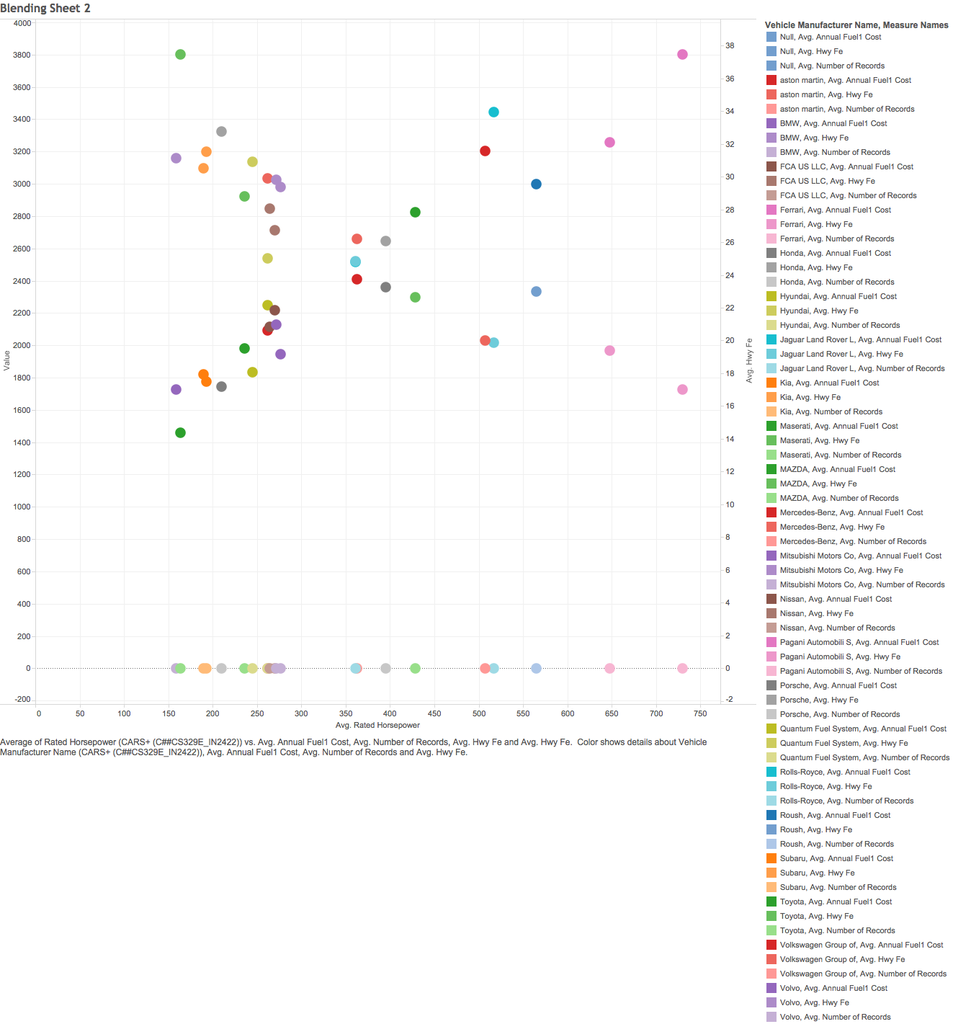

### Tableau Blended Scatter Plot:

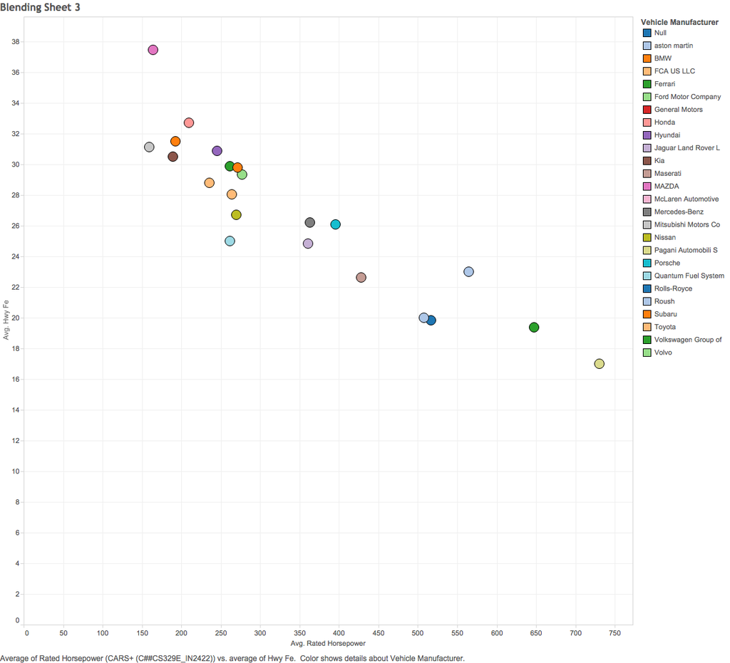